# 市场观察

### (c5)主动量化基金

主动量化基金最近一年和最近一个季度的收益率密度图如下所示。

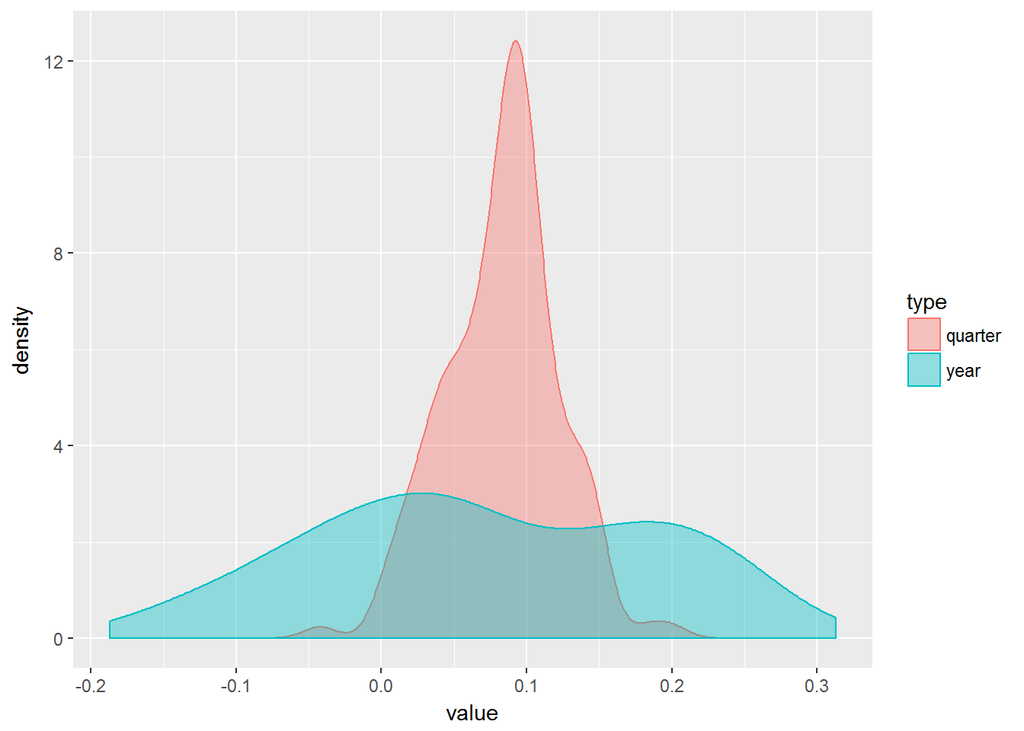

主动量化基金近一年和近一个季度表现最好的20只基金如下表所示。

| 季度排名 | 基金简称 | 成立日 | 总规模 | 季度收益 | 年度排名 | 基金简称 | 成立日 | 总规模 | 年度收益 |
| --- | --- | --- | --- | --- | --- | --- | --- | --- | --- |
| 1 | 九泰久盛量化先锋A | 2015-11-10 | 4.3 | 18.3% | 1 | 景顺长城量化新动力 | 2016-07-13 | 4.0 | 31.3% |
| 2 | 中融量化智选A | 2017-03-22 | 2.5 | 15.1% | 2 | 华泰柏瑞量化优选 | 2014-12-17 | 9.1 | 28.1% |
| 3 | 华泰柏瑞量化先行 | 2010-06-22 | 7.8 | 15.1% | 3 | 华泰柏瑞量化驱动 | 2015-03-24 | 21.8 | 24.3% |
| 4 | 华泰柏瑞量化优选 | 2014-12-17 | 9.1 | 14.9% | 4 | 华泰柏瑞量化A | 2013-08-02 | 44.3 | 23.8% |
| 5 | 华泰柏瑞量化智慧 | 2015-06-03 | 5.6 | 14.8% | 5 | 华泰柏瑞量化智慧 | 2015-06-03 | 5.6 | 22.5% |
| 6 | 嘉实腾讯自选股大数据 | 2015-12-07 | 5.5 | 14.3% | 6 | 华泰柏瑞量化先行 | 2010-06-22 | 7.8 | 21.2% |
| 7 | 德邦量化优选A | 2017-03-24 | 0.1 | 13.9% | 7 | 九泰久盛量化先锋A | 2015-11-10 | 4.3 | 18.1% |
| 8 | 景顺长城量化精选 | 2015-02-04 | 14.0 | 13.8% | 8 | 景顺长城量化精选 | 2015-02-04 | 14.0 | 12.1% |
| 9 | 华泰柏瑞量化驱动 | 2015-03-24 | 21.8 | 13.8% | 9 | 永赢量化灵活配置 | 2015-09-01 | 0.7 | 11.2% |
| 10 | 华泰柏瑞量化A | 2013-08-02 | 44.3 | 13.8% | 10 | 大成核心双动力 | 2010-06-22 | 1.3 | 10.9% |
| 11 | 景顺长城量化新动力 | 2016-07-13 | 4.0 | 12.7% | 11 | 泰达宏利同顺大数据A | 2016-02-23 | 1.8 | 10.7% |
| 12 | 永赢量化灵活配置 | 2015-09-01 | 0.7 | 12.7% | 12 | 工银瑞信量化策略 | 2012-04-26 | 1.7 | 9.6% |
| 13 | 建信多因子量化 | 2016-08-09 | 1.7 | 11.1% | 13 | 东吴安鑫量化 | 2016-06-03 | 2.4 | 8.0% |
| 14 | 泰达宏利同顺大数据A | 2016-02-23 | 1.8 | 10.9% | 14 | 泰达宏利量化 | 2016-08-30 | 2.4 | 7.8% |
| 15 | 泰达宏利量化 | 2016-08-30 | 2.4 | 10.5% | 15 | 华商大盘量化精选 | 2013-04-09 | 11.6 | 6.3% |
| 16 | 大成动态量化 | 2016-09-20 | 2.5 | 10.1% | 16 | 嘉实腾讯自选股大数据 | 2015-12-07 | 5.5 | 4.9% |
| 17 | 大成核心双动力 | 2010-06-22 | 1.3 | 10.0% | 17 | 建信多因子量化 | 2016-08-09 | 1.7 | 4.7% |
| 18 | 光大事件驱动 | 2017-01-18 | 5.7 | 9.9% | 18 | 泰达宏利改革动力A | 2015-02-13 | 16.6 | 4.7% |
| 19 | 诺安多策略 | 2011-08-09 | 0.5 | 9.8% | 19 | 大摩量化配置 | 2012-12-11 | 17.1 | 4.6% |
| 20 | 工银瑞信量化策略 | 2012-04-26 | 1.7 | 9.6% | 20 | 诺安多策略 | 2011-08-09 | 0.5 | 3.7% |

指数增强基金表现如下所示。

| 基金代码 | 基金简称 | 成立日 | 总规模 | 季度超额收益 | 年度超额收益 |
| --- | --- | --- | --- | --- | --- |
| 110003.OF | 易方达上证50指数A | 2004-03-22 | 96.2 | 0.7% | 3.7% |
| 399001.OF | 中海上证50 | 2010-03-25 | 1.4 | -0.7% | -4.2% |
| 000312.OF | 华安沪深300量化A | 2013-09-27 | 1.7 | 4.7% | 8.3% |
| 110030.OF | 易方达沪深300量化 | 2013-06-07 | 9.2 | 3.8% | 9.0% |
| 100038.OF | 富国沪深300 | 2009-12-16 | 20.9 | 1.7% | 3.0% |
| 000311.OF | 景顺长城沪深300 | 2013-10-29 | 27.0 | 1.5% | 11.1% |
| 003015.OF | 中金沪深300A | 2016-07-22 | 0.1 | 0.9% | -4.7% |
| 000176.OF | 嘉实沪深300增强 | 2014-12-26 | 4.6 | 0.6% | 2.5% |
| 310318.OF | 申万菱信沪深300 | 2013-06-07 | 8.3 | 0.3% | 5.4% |
| 003261.OF | 安信沪深300A | 2016-10-12 | 1.5 | 0.1% |  |
| 004190.OF | 招商沪深300A | 2017-02-10 | 2.2 | -0.3% |  |
| 163407.OF | 兴全沪深300 | 2010-11-02 | 8.9 | -0.7% | 7.9% |
| 003876.OF | 华宝兴业沪深300 | 2016-12-09 | 3.5 | -0.7% |  |
| 200002.OF | 长城久泰沪深300 | 2004-05-21 | 7.8 | -1.3% | 1.4% |
| 001015.OF | 华夏沪深300A | 2015-02-10 | 3.1 | -1.8% | -0.6% |
| 519116.OF | 浦银安盛沪深300 | 2010-12-10 | 1.3 | -1.9% | 2.9% |
| 002310.OF | 创金合信沪深300A | 2015-12-31 | 2.3 | -2.1% | -1.4% |
| 166007.OF | 中欧沪深300A | 2010-06-24 | 0.7 | -2.4% | -2.4% |
| 450008.OF | 国富沪深300 | 2009-09-03 | 2.6 | -5.5% | -4.9% |
| 004194.OF | 招商中证1000A | 2017-03-03 | 1.4 | 0.8% |  |
| 003646.OF | 创金合信中证1000A | 2016-12-22 | 1.9 | 0.6% |  |
| 164508.OF | 国富中证100 | 2015-03-26 | 1.7 | 0.6% | 0.6% |
| 213010.OF | 宝盈中证100 | 2010-02-08 | 1.9 | -0.5% | -0.0% |
| 163808.OF | 中银中证100 | 2009-09-04 | 3.2 | -1.1% | 2.6% |
| 003986.OF | 申万菱信中证500优选 | 2017-01-10 | 3.5 | 7.6% |  |
| 002906.OF | 南方中证500增强A | 2016-11-23 | 1.9 | 0.5% |  |
| 003016.OF | 中金中证500A | 2016-07-22 | 0.1 | -0.2% | 0.1% |
| 004192.OF | 招商中证500A | 2017-05-17 | NA | -0.5% |  |
| 161017.OF | 富国中证500 | 2011-10-12 | 9.0 | -0.5% | 4.8% |
| 000478.OF | 建信中证500 | 2014-01-27 | 12.8 | -1.4% | 4.0% |
| 002311.OF | 创金合信中证500A | 2015-12-31 | 1.7 | -2.6% | 3.0% |
| 002510.OF | 申万菱信中证500 | 2016-04-21 | 2.4 | -6.3% | -5.9% |
| 700002.OF | 平安大华深证300 | 2011-12-20 | 0.6 | -0.6% | 1.3% |
| 233010.OF | 大摩深证300 | 2011-11-15 | 0.5 | -5.0% | -3.0% |
| 530018.OF | 建信深证100 | 2012-03-16 | 1.0 | -2.3% | 1.7% |
| 165806.OF | 东吴深证100 | 2012-03-09 | 0.1 | -4.9% | -8.0% |

## D、择时

### (d1)等权指数

从历史来看，A股市场存在小盘股效应，市值小的股票长期整体跑赢大市值的股票，美股市场同样存在类似的现象。而目前大部分指数的编制方案都是类似市值加权，为了抛去市值的影响，下面展示几个等权指数，其中中证500等权和沪深300等权是现有的指数，中证全指等权是自己编制的指数。等权指数可以视为一个更好地业绩比较基准。等权指数走势如下图：

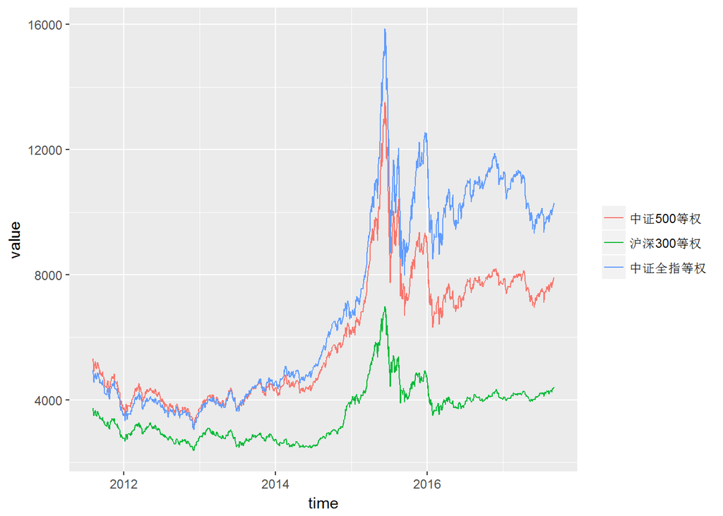

等权指数收益率统计见下表：

|  | 中证500等权 | 沪深300等权 | 中证全指等权 |
| --- | --- | --- | --- |
| 2011-08-02 ~ 2011-12-30 | -29.2% | -25.5% | -27.8% |
| 2012-01-04 ~ 2012-12-31 | -0.0% | 1.5% | 2.2% |
| 2013-01-04 ~ 2013-12-31 | 16.7% | -3.2% | 25.8% |
| 2014-01-02 ~ 2014-12-31 | 40.2% | 43.7% | 46.0% |
| 2015-01-05 ~ 2015-12-31 | 47.6% | 20.1% | 84.4% |
| 2016-01-04 ~ 2016-12-30 | -15.1% | -15.1% | -10.3% |
| 2017-01-03 ~ 2017-09-04 | 3.0% | 9.8% | -6.7% |
| 累计收益率 | 49.5% | 17.9% | 109.2% |
| 年化收益率 | 6.8% | 2.7% | 12.9% |
| 年化波动率 | 28.1% | 25.3% | 28.4% |
| 年化Sharpe值 | 24.3% | 10.8% | 45.2% |
| 最大回撤 | 53.3% | 50.0% | 49.7% |

### (d2)大盘均线强弱指数

大盘均线强弱指数在一定程度上可以视为一个反转指标，当大盘均线得分接近8分时，预示市场接近顶部，当大盘均线得分接近0分时，预示市场接近底部。  
大盘均线强弱指数近一年来走势如下图：

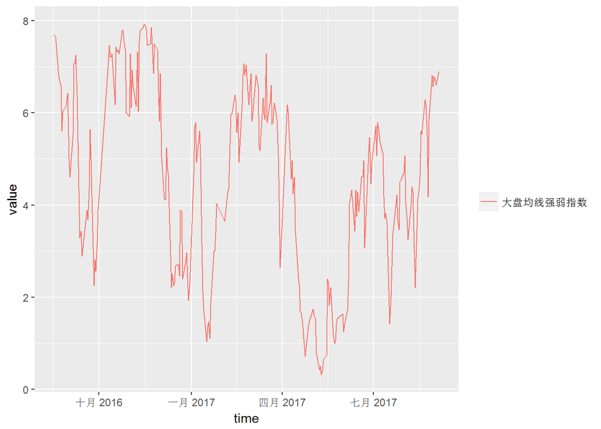

申万一级行业的最新得分见下表：

| 日期 | 指数代码 | 行业 | 最新得分 | 上周得分 |
| --- | --- | --- | --- | --- |
| 2017-09-04 | EI801020 | 采掘 | 8 | 8 |
| 2017-09-04 | EI801030 | 化工 | 8 | 7 |
| 2017-09-04 | EI801040 | 钢铁 | 8 | 7 |
| 2017-09-04 | EI801050 | 有色金属 | 8 | 8 |
| 2017-09-04 | EI801080 | 电子 | 8 | 8 |
| 2017-09-04 | EI801120 | 食品饮料 | 8 | 7 |
| 2017-09-04 | EI801170 | 交通运输 | 8 | 8 |
| 2017-09-04 | EI801710 | 建筑材料 | 8 | 8 |
| 2017-09-04 | EI801720 | 建筑装饰 | 8 | 8 |
| 2017-09-04 | EI801750 | 计算机 | 8 | 7 |
| 2017-09-04 | EI801790 | 非银金融 | 8 | 8 |
| 2017-09-04 | EI801150 | 医药生物 | 7 | 6 |
| 2017-09-04 | EI801210 | 休闲服务 | 7 | 3 |
| 2017-09-04 | EI801230 | 综合 | 7 | 6 |
| 2017-09-04 | EI801770 | 通信 | 7 | 7 |
| 2017-09-04 | EI801780 | 银行 | 7 | 8 |
| 2017-09-04 | EI801010 | 农林牧渔 | 6 | 6 |
| 2017-09-04 | EI801130 | 纺织服装 | 6 | 5 |
| 2017-09-04 | EI801140 | 轻工制造 | 6 | 6 |
| 2017-09-04 | EI801160 | 公用事业 | 6 | 6 |
| 2017-09-04 | EI801180 | 房地产 | 6 | 7 |
| 2017-09-04 | EI801200 | 商业贸易 | 6 | 6 |
| 2017-09-04 | EI801730 | 电气设备 | 6 | 6 |
| 2017-09-04 | EI801740 | 国防军工 | 6 | 3 |
| 2017-09-04 | EI801760 | 传媒 | 6 | 5 |
| 2017-09-04 | EI801880 | 汽车 | 6 | 6 |
| 2017-09-04 | EI801890 | 机械设备 | 6 | 6 |
| 2017-09-04 | EI801110 | 家用电器 | 4 | 8 |

### (d3)LLT及均线择时

LLT本质上是一个改进的单均线择时指标，较原始的均线择时延迟更低。  
择时模型和指数本身的净值走势如下图：

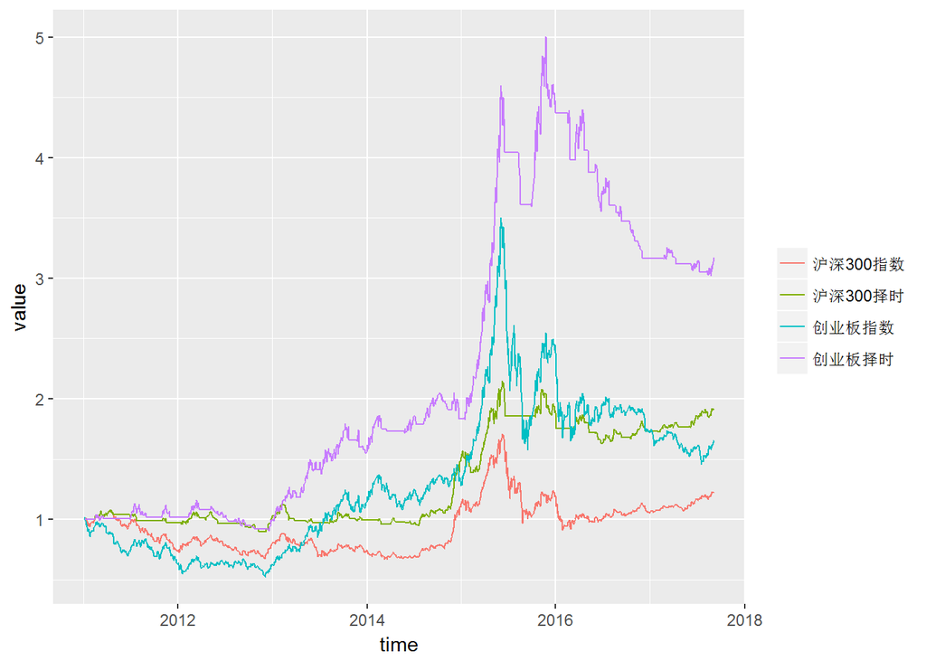

择时模型和指数的收益率统计如下表：

|  | 沪深300指 | 沪深300LLT | 创业板指 | 创业板MA |
| --- | --- | --- | --- | --- |
| 2011-01-04 ~ 2011-12-30 | -25.0% | -2.5% | -35.9% | 1.9% |
| 2012-01-04 ~ 2012-12-31 | 7.6% | 5.4% | -2.1% | -1.7% |
| 2013-01-04 ~ 2013-12-31 | -7.6% | -3.2% | 82.7% | 55.7% |
| 2014-01-02 ~ 2014-12-31 | 51.7% | 52.4% | 12.8% | 17.7% |
| 2015-01-05 ~ 2015-12-31 | 5.6% | 24.3% | 84.4% | 138.1% |
| 2016-01-04 ~ 2016-12-30 | -11.3% | -8.1% | -27.7% | -27.5% |
| 2017-01-03 ~ 2017-09-04 | 16.2% | 10.8% | -4.0% | 0.1% |
| 累计收益率 | 22.9% | 92.1% | 65.6% | 216.9% |
| 年化收益率 | 3.1% | 10.3% | 7.8% | 18.9% |
| 年化波动率 | 23.5% | 15.1% | 32.0% | 21.5% |
| 年化Sharpe值 | 13.4% | 67.9% | 24.5% | 87.8% |
| 最大回撤 | 46.7% | 24.0% | 58.4% | 39.6% |

择时模型最近10个交易日的信号如下表：

| 日期 | 沪深300收盘价 | 沪深300LLT | 沪深300择时信号 | 创业板收盘价 | 创业板MA30 | 创业板择时信号 |
| --- | --- | --- | --- | --- | --- | --- |
| 2017-08-22 | 3752.298 | 3745.829 | hold | 1814.915 | 1745.199 | hold |
| 2017-08-23 | 3756.088 | 3749.428 | hold | 1807.366 | 1745.886 | hold |
| 2017-08-24 | 3734.646 | 3752.226 | hold | 1795.739 | 1746.449 | hold |
| 2017-08-25 | 3795.754 | 3756.126 | hold | 1812.878 | 1748.692 | hold |
| 2017-08-28 | 3842.712 | 3763.298 | hold | 1842.829 | 1754.906 | hold |
| 2017-08-29 | 3834.538 | 3771.329 | hold | 1831.591 | 1760.376 | hold |
| 2017-08-30 | 3834.300 | 3778.641 | hold | 1838.631 | 1765.504 | hold |
| 2017-08-31 | 3822.093 | 3785.136 | hold | 1849.379 | 1770.863 | hold |
| 2017-09-01 | 3830.538 | 3791.137 | hold | 1865.250 | 1776.700 | hold |
| 2017-09-04 | 3845.616 | 3797.553 | hold | 1883.618 | 1783.273 | hold |

### (d4)网格交易

在经历了三轮股灾，A股逐步回归正常，在过去的一段时间呈现一个震荡的格局，如果未来没有增量信息，很可能维持震荡。结合股指期货的贴水，前期研究了一下网格交易。网格交易的结果如下图：

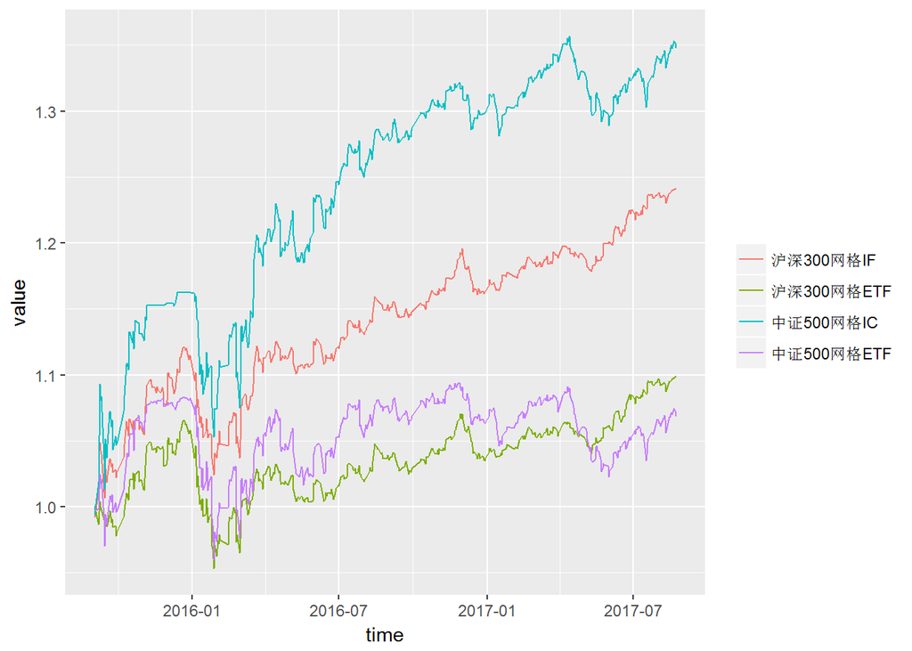

网格交易的收益统计如下表：

|  | 沪深300指数 | 沪深300网格IF | 沪深300网格ETF | 中证500指数 | 中证500网格IC | 中证500网格ETF |
| --- | --- | --- | --- | --- | --- | --- |
| 2015-09-02 ~ 2015-12-31 | 11.0% | 11.1% | 5.6% | 23.5% | 16.2% | 8.1% |
| 2016-01-04 ~ 2016-12-30 | -11.3% | 4.7% | -1.8% | -17.8% | 11.8% | -1.6% |
| 2017-01-03 ~ 2017-08-23 | 13.5% | 6.8% | 6.0% | 0.9% | 3.7% | 0.4% |
| 累计收益率 | 11.7% | 24.2% | 9.9% | 2.5% | 34.7% | 6.8% |
| 年化收益率 | 5.8% | 11.6% | 4.9% | 1.2% | 16.3% | 3.4% |
| 年化波动率 | 20.1% | 8.3% | 8.2% | 27.3% | 12.4% | 10.7% |
| 年化Sharpe值 | 28.7% | 138.5% | 59.7% | 4.6% | 131.3% | 31.7% |
| 最大回撤 | 26.4% | 8.6% | 10.5% | 33.5% | 9.4% | 11.4% |

## E、选股

### (e1)大小市值100

作为多因子选股的第一部分，有必要从市值因子说起。 下面利用总市值因子，在中证全指的成分股内，选出市值最大和最小的100只股票，这里剔除了ST、新上市、停牌和涨停的股票，等权配置，每月换仓一次，交易成本千分之三。观察历年来大、小市值组净值表现如下图。

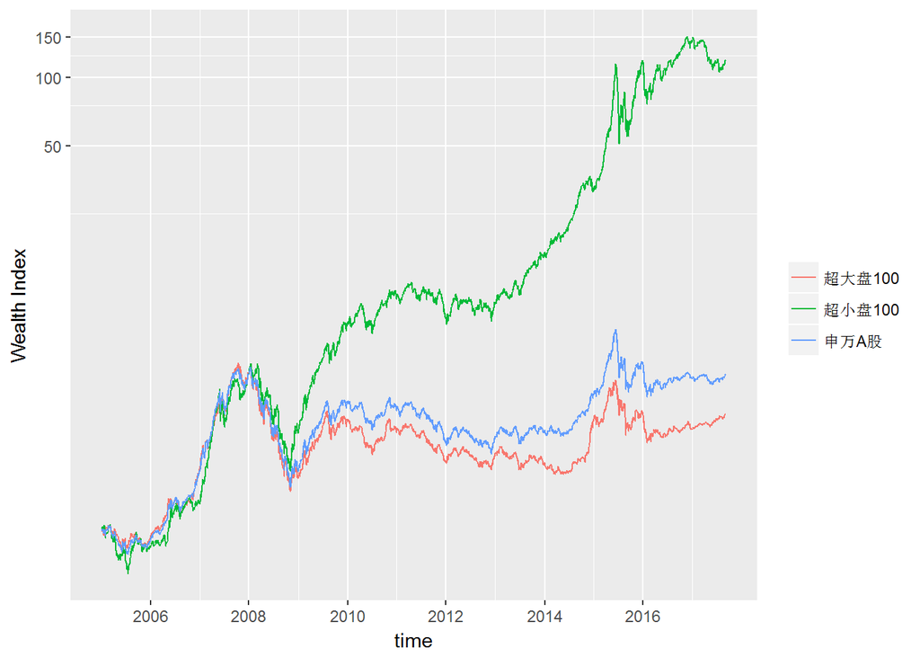

大小市值100的收益统计如下表：

|  | 超大盘100 | 超小盘100 | 申万A股 |
| --- | --- | --- | --- |
| 2005-01-05 ~ 2005-12-30 | -8.0% | -15.5% | -10.1% |
| 2006-01-04 ~ 2006-12-29 | 104.5% | 56.5% | 103.9% |
| 2007-01-04 ~ 2007-12-28 | 163.5% | 270.9% | 167.2% |
| 2008-01-02 ~ 2008-12-31 | -65.6% | -45.1% | -62.8% |
| 2009-01-05 ~ 2009-12-31 | 82.8% | 206.5% | 105.6% |
| 2010-01-04 ~ 2010-12-31 | -9.9% | 32.0% | -6.8% |
| 2011-01-04 ~ 2011-12-30 | -27.2% | -19.5% | -28.6% |
| 2012-01-04 ~ 2012-12-31 | 7.7% | 15.8% | 4.9% |
| 2013-01-04 ~ 2013-12-31 | -9.2% | 65.4% | 6.3% |
| 2014-01-02 ~ 2014-12-31 | 55.5% | 89.8% | 44.9% |
| 2015-01-05 ~ 2015-12-31 | 4.5% | 266.7% | 35.3% |
| 2016-01-04 ~ 2016-12-30 | -13.5% | 24.7% | -13.6% |
| 2017-01-03 ~ 2017-09-04 | 16.4% | -17.7% | 4.4% |
| 累计收益率 | 227.4% | 11898.5% | 391.4% |
| 年化收益率 | 9.8% | 45.9% | 13.4% |
| 年化波动率 | 28.7% | 35.5% | 28.3% |
| 年化Sharpe值 | 34.1% | 129.4% | 47.3% |
| 最大回撤 | 72.9% | 66.4% | 70.5% |

### (e2)银行股轮动

银行股轮动是参考集思录的热门贴银行股评级而来的，数据的提取和参数的设置和原贴有一定的差别，所以轮动的效果也会不太一样，不过回测的效果还不错，从现在开始跟踪。2013年以来银行股轮动的结果如下图：

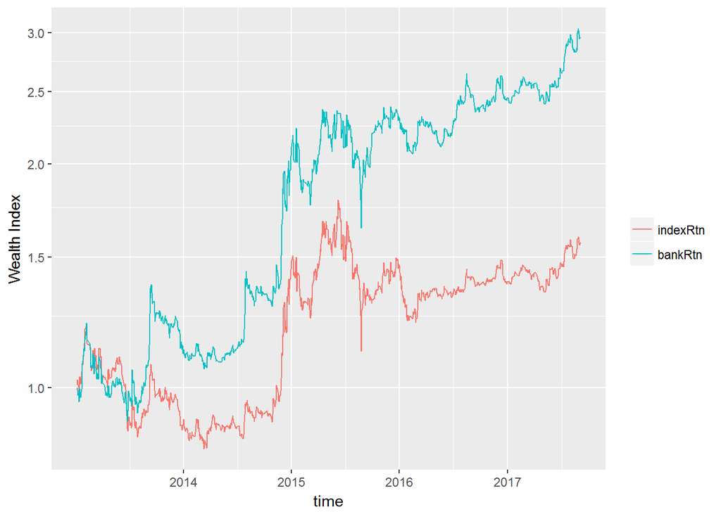

银行股轮动的收益统计如下表：

|  | 申万银行 | 银行股轮动 |
| --- | --- | --- |
| 2013-01-04 ~ 2013-12-31 | -9.2% | 12.5% |
| 2014-01-02 ~ 2014-12-31 | 63.2% | 87.6% |
| 2015-01-05 ~ 2015-12-31 | -1.4% | 9.4% |
| 2016-01-04 ~ 2016-12-30 | -4.9% | 6.2% |
| 2017-01-04 ~ 2017-09-04 | 13.0% | 20.8% |
| 累计收益率 | 57.0% | 196.3% |
| 年化收益率 | 10.1% | 26.2% |
| 年化波动率 | 27.2% | 29.2% |
| 年化Sharpe值 | 37.2% | 89.6% |
| 最大回撤 | 37.4% | 30.8% |

银行股轮动的最新得分如下表：

| 日期 | 代码 | 简称 | PB | ROE | 翻倍期 | 持仓 |
| --- | --- | --- | --- | --- | --- | --- |
| 2017-09-04 | EQ600015 | 华夏银行 | 0.80 | 0.12 | 4.1 |  |
| 2017-09-04 | EQ601818 | 光大银行 | 0.78 | 0.12 | 4.1 |  |
| 2017-09-04 | EQ601328 | 交通银行 | 0.77 | 0.11 | 4.3 | hold |
| 2017-09-04 | EQ600016 | 民生银行 | 0.89 | 0.14 | 4.6 |  |
| 2017-09-04 | EQ601288 | 农业银行 | 0.92 | 0.14 | 4.8 |  |
| 2017-09-04 | EQ601998 | 中信银行 | 0.84 | 0.11 | 5.1 |  |
| 2017-09-04 | EQ600000 | 浦发银行 | 0.98 | 0.14 | 5.1 |  |
| 2017-09-04 | EQ601988 | 中国银行 | 0.88 | 0.11 | 5.2 |  |
| 2017-09-04 | EQ601166 | 兴业银行 | 1.05 | 0.14 | 5.7 |  |
| 2017-09-04 | EQ601169 | 北京银行 | 0.98 | 0.12 | 5.9 |  |
| 2017-09-04 | EQ601939 | 建设银行 | 1.09 | 0.14 | 5.9 |  |
| 2017-09-04 | EQ601398 | 工商银行 | 1.06 | 0.14 | 5.9 |  |
| 2017-09-04 | EQ601009 | 南京银行 | 1.12 | 0.14 | 6.2 |  |
| 2017-09-04 | EQ000001 | 平安银行 | 1.00 | 0.11 | 6.7 |  |
| 2017-09-04 | EQ600919 | 江苏银行 | 1.23 | 0.13 | 7.4 |  |
| 2017-09-04 | EQ601997 | 贵阳银行 | 1.71 | 0.17 | 7.7 |  |
| 2017-09-04 | EQ601229 | 上海银行 | 1.27 | 0.12 | 8.1 |  |
| 2017-09-04 | EQ002142 | 宁波银行 | 1.66 | 0.16 | 8.2 |  |
| 2017-09-04 | EQ600036 | 招商银行 | 1.69 | 0.16 | 8.3 |  |
| 2017-09-04 | EQ600926 | 杭州银行 | 1.41 | 0.10 | 10.5 |  |
| 2017-09-04 | EQ601128 | 常熟银行 | 2.46 | 0.11 | 15.3 |  |
| 2017-09-04 | EQ600908 | 无锡银行 | 2.40 | 0.11 | 15.6 |  |
| 2017-09-04 | EQ002807 | 江阴银行 | 2.25 | 0.09 | 17.9 |  |
| 2017-09-04 | EQ603323 | 吴江银行 | 2.26 | 0.09 | 18.3 |  |
| 2017-09-04 | EQ002839 | 张家港行 | 3.54 | 0.09 | 23.0 |  |

## F、多因子跟踪

### (f1)近一个月周频因子IC

全市场因子IC表现如下图所示，根据因子IC均值大于0，胜率大于50%简单区分了一下alpha因子和风险因子。

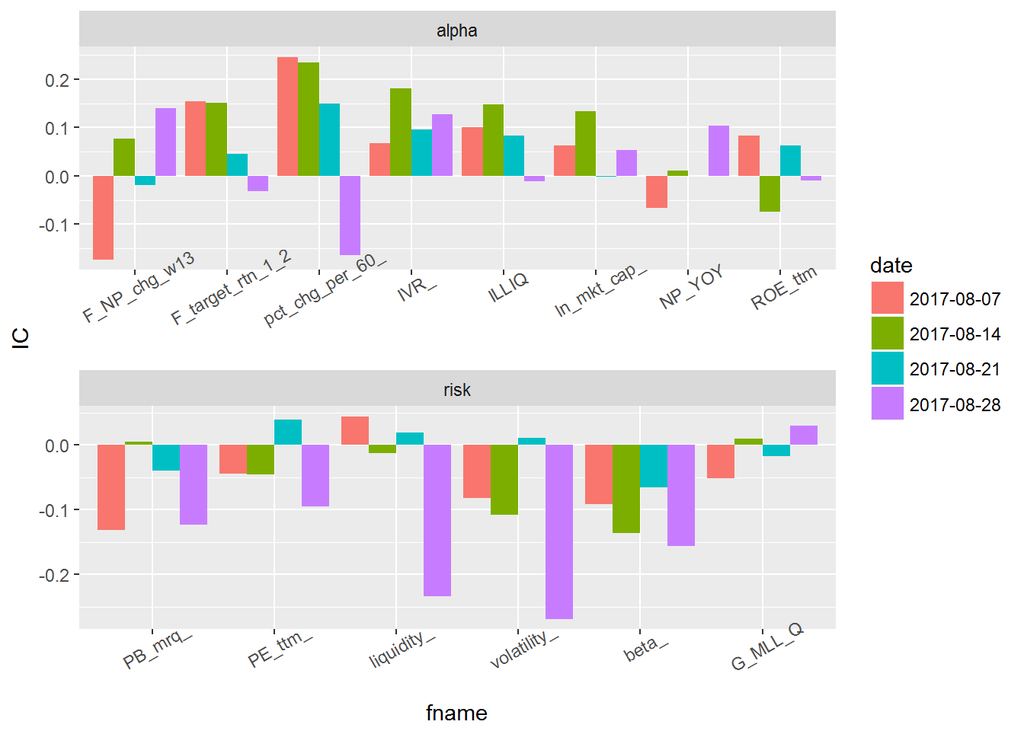

沪深300因子IC表现如下图所示。

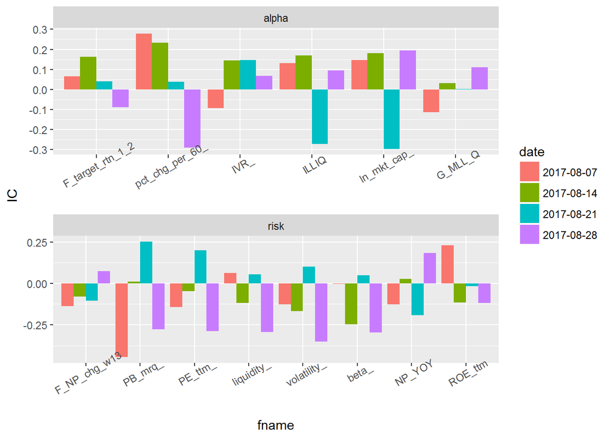

中证500因子IC表现如下图所示。

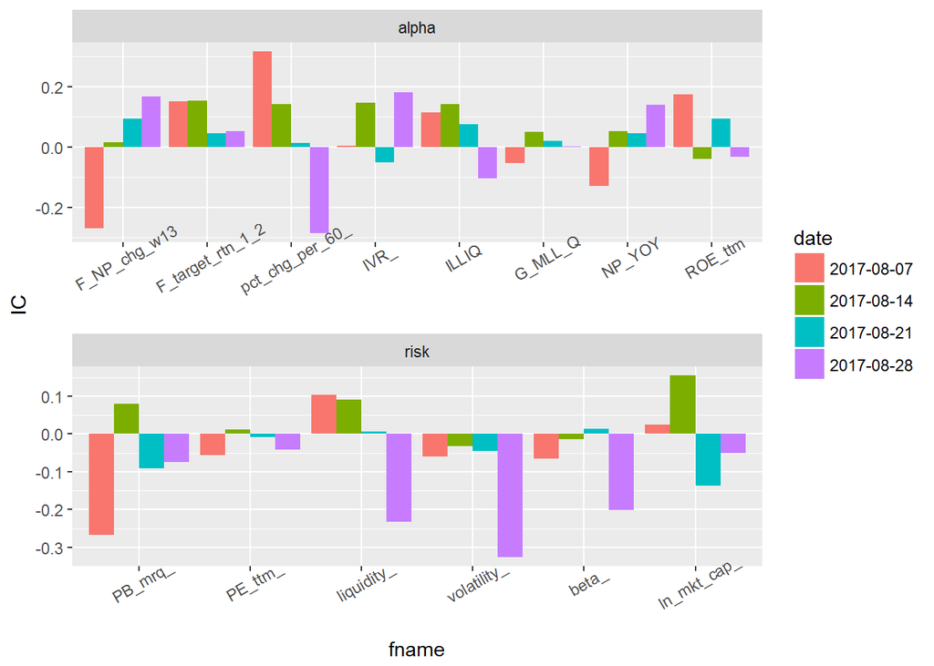

因子IC统计如下表所示。

| 因子名 | 全市场排名 | 全市场均值 | 全市场胜率 | 沪深300排名 | 沪深300均值 | 沪深300胜率 | 中证500排名 | 中证500均值 | 中证500胜率 |
| --- | --- | --- | --- | --- | --- | --- | --- | --- | --- |
| IVR_ | 1 | 0.118 | 1.00 | 1 | 0.066 | 0.75 | 2 | 0.070 | 0.75 |
| pct_chg_per_60_ | 2 | 0.117 | 0.75 | 2 | 0.065 | 0.75 | 5 | 0.046 | 0.75 |
| ILLIQ | 3 | 0.080 | 0.75 | 5 | 0.031 | 0.75 | 3 | 0.056 | 0.75 |
| F_target_rtn_1_2 | 4 | 0.080 | 0.75 | 4 | 0.045 | 0.75 | 1 | 0.101 | 1.00 |
| ln_mkt_cap_ | 5 | 0.062 | 0.75 | 3 | 0.056 | 0.75 | 9 | -0.002 | 0.50 |
| ROE_ttm | 6 | 0.016 | 0.50 | 7 | -0.005 | 0.25 | 4 | 0.049 | 0.50 |
| NP_YOY | 7 | 0.012 | 0.50 | 8 | -0.027 | 0.50 | 6 | 0.027 | 0.75 |
| F_NP_chg_w13 | 8 | 0.006 | 0.50 | 9 | -0.063 | 0.25 | 8 | 0.002 | 0.75 |
| G_MLL_Q | 9 | -0.007 | 0.50 | 6 | 0.008 | 0.75 | 7 | 0.005 | 0.75 |
| PE_ttm_ | 10 | -0.036 | 0.25 | 10 | -0.069 | 0.25 | 11 | -0.024 | 0.25 |
| liquidity_ | 11 | -0.046 | 0.50 | 11 | -0.074 | 0.50 | 10 | -0.008 | 0.75 |
| PB_mrq_ | 12 | -0.072 | 0.25 | 12 | -0.115 | 0.50 | 13 | -0.088 | 0.25 |
| volatility_ | 13 | -0.112 | 0.25 | 14 | -0.136 | 0.25 | 14 | -0.115 | 0.00 |
| beta_ | 14 | -0.112 | 0.00 | 13 | -0.124 | 0.25 | 12 | -0.067 | 0.25 |

### (f2)近一个月周频因子分组超额收益

全市场，不同时间段，根据因子得分分为10组，得分最高的组**超额**收益率如下图所示，根据累计收益率大于0和区间收益率为正概率大于0.5,简单区分了alpha因子和风险因子。

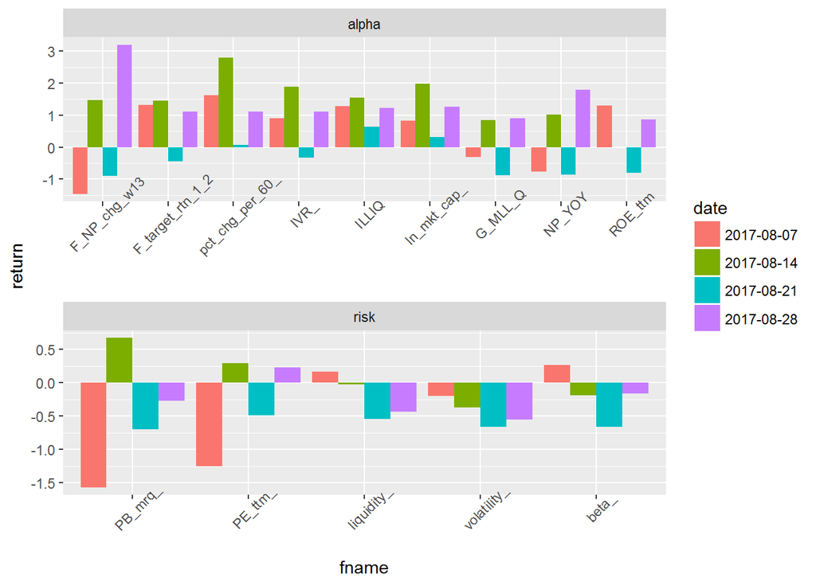

沪深300内得分最高的组**超额**收益率如下图所示。

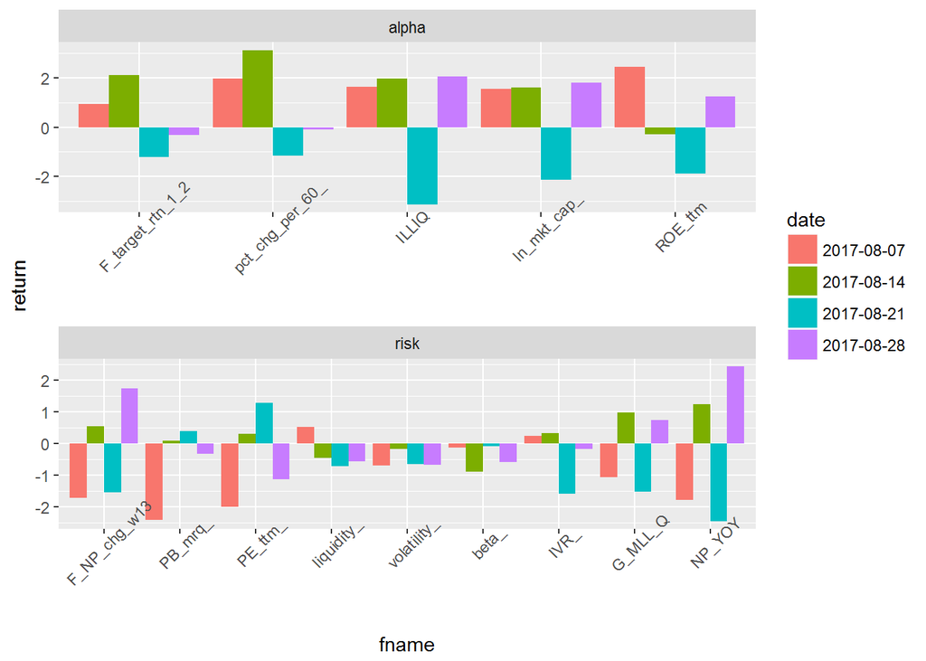

[figure not shown]

各个样本空间内，因子得分最高的一组和得分最低的一组的**超额**累积收益率统计如下表所示。

| 因子名 | 全市场Q1 | 全市场Q10 | 沪深300Q1 | 沪深300Q10 | 中证500Q1 | 中证500Q10 |
| --- | --- | --- | --- | --- | --- | --- |
| pct_chg_per_60_ | 5.7 | -1.0 | 3.9 | -1.1 | 2.3 | -1.3 |
| ILLIQ | 4.8 | -0.1 | 2.5 | 0.4 | 4.5 | -0.9 |
| ln_mkt_cap_ | 4.5 | -0.3 | 2.8 | -1.2 | 0.3 | -0.6 |
| IVR_ | 3.6 | -1.3 | -1.2 | -1.4 | 1.9 | -2.8 |
| F_target_rtn_1_2 | 3.5 | -0.8 | 1.5 | -1.2 | 1.5 | -3.5 |
| F_NP_chg_w13 | 2.3 | 2.5 | -1.0 | 3.9 | -1.0 | 0.7 |
| ROE_ttm | 1.3 | 0.4 | 1.5 | -0.4 | 2.1 | -1.0 |
| NP_YOY | 1.2 | 0.5 | -0.6 | 1.8 | 0.4 | -0.4 |
| G_MLL_Q | 0.6 | 1.3 | -0.9 | -0.9 | 0.5 | 0.1 |
| beta_ | -0.7 | 5.8 | -1.7 | 5.1 | -0.9 | 3.7 |
| liquidity_ | -0.8 | 1.6 | -1.2 | 2.1 | -1.0 | -0.9 |
| PE_ttm_ | -1.2 | 1.8 | -1.6 | 1.3 | -0.9 | 0.9 |
| volatility_ | -1.8 | 5.4 | -2.2 | 4.1 | -3.7 | 3.3 |
| PB_mrq_ | -1.9 | 3.1 | -2.2 | 2.8 | -2.3 | 3.1 |

### (f3)近一年月频因子IC

全市场因子IC表现如下图所示。

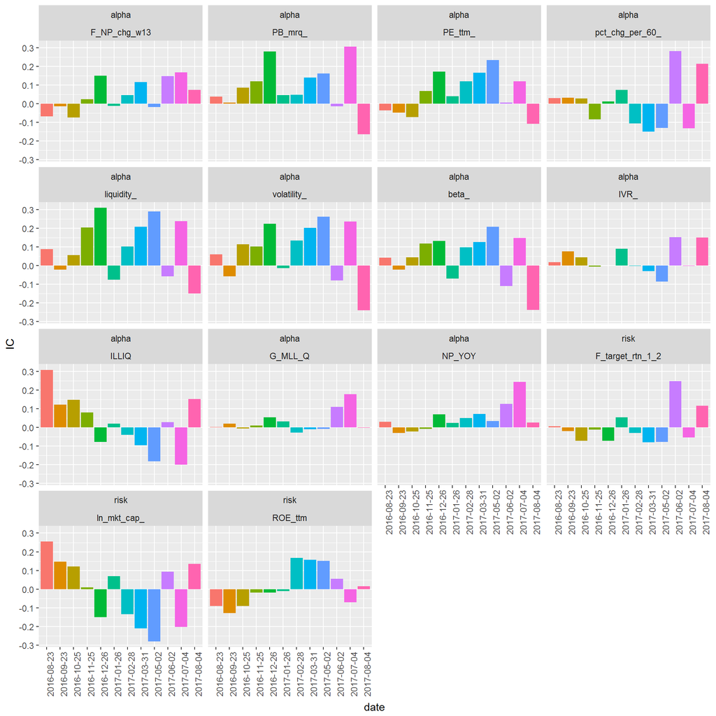

沪深300因子IC表现如下图所示。

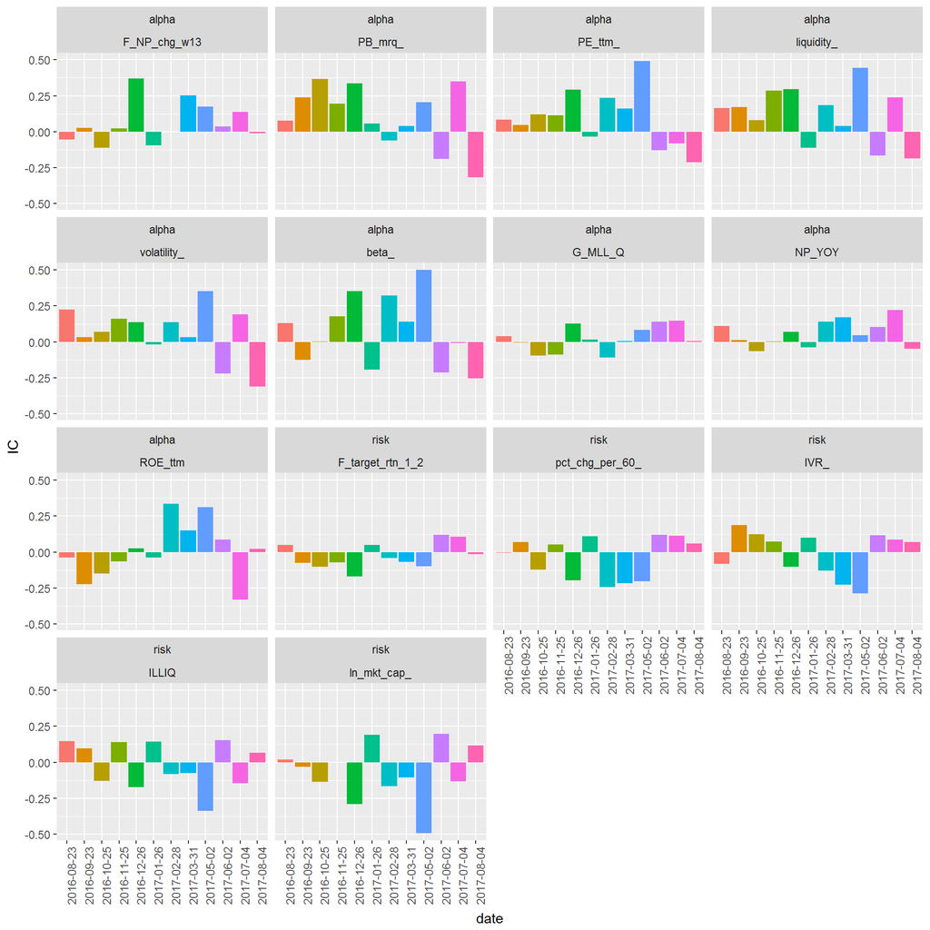

中证500因子IC表现如下图所示。

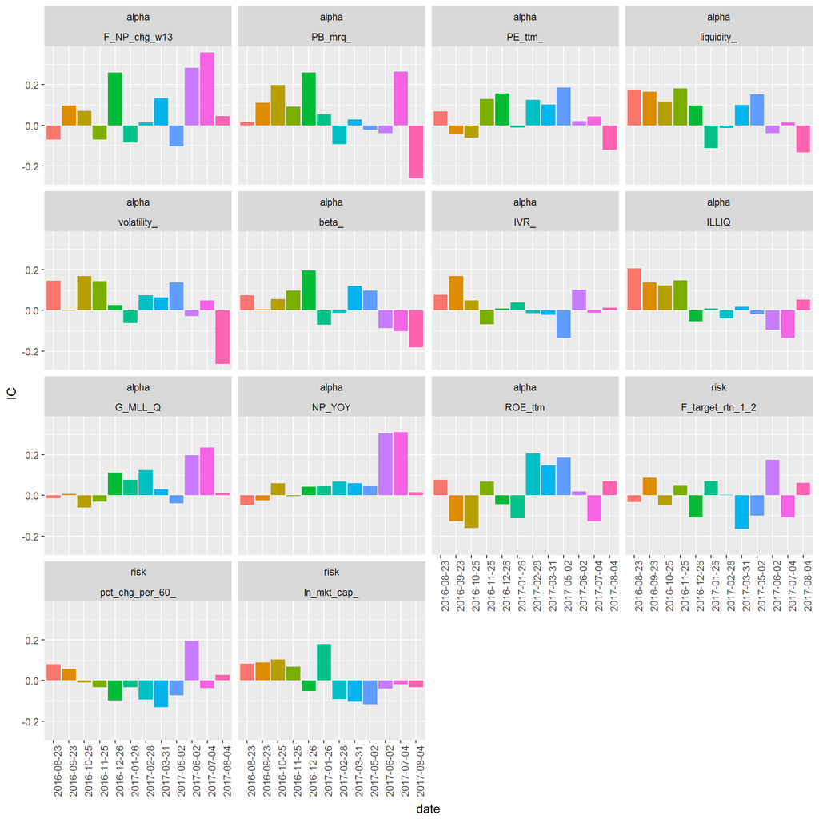

因子IC统计如下表所示。

|  | 因子名 | 全市场排名 | 全市场均值 | 全市场胜率 | 沪深300排名 | 沪深300均值 | 沪深300胜率 | 中证500排名 | 中证500均值 | 中证500胜率 |
| --- | --- | --- | --- | --- | --- | --- | --- | --- | --- | --- |
| 15 | liquidity_ | 1 | 0.098 | 0.67 | 1 | 0.120 | 0.75 | 3 | 0.059 | 0.67 |
| 16 | PB_mrq_ | 2 | 0.088 | 0.83 | 2 | 0.108 | 0.75 | 5 | 0.050 | 0.67 |
| 17 | volatility_ | 3 | 0.078 | 0.67 | 5 | 0.066 | 0.75 | 7 | 0.038 | 0.67 |
| 18 | PE_ttm_ | 4 | 0.055 | 0.67 | 3 | 0.091 | 0.67 | 6 | 0.049 | 0.67 |
| 19 | NP_YOY | 5 | 0.051 | 0.75 | 7 | 0.061 | 0.75 | 2 | 0.073 | 0.75 |
| 20 | F_NP_chg_w13 | 6 | 0.045 | 0.58 | 6 | 0.062 | 0.58 | 1 | 0.078 | 0.67 |
| 21 | beta_ | 7 | 0.040 | 0.67 | 4 | 0.070 | 0.58 | 11 | 0.016 | 0.58 |
| 22 | IVR_ | 8 | 0.033 | 0.58 | 10 | -0.006 | 0.58 | 9 | 0.017 | 0.58 |
| 23 | G_MLL_Q | 9 | 0.029 | 0.58 | 8 | 0.023 | 0.67 | 4 | 0.054 | 0.67 |
| 24 | ILLIQ | 10 | 0.021 | 0.58 | 11 | -0.017 | 0.50 | 8 | 0.030 | 0.58 |
| 25 | ROE_ttm | 11 | 0.010 | 0.42 | 9 | 0.008 | 0.50 | 10 | 0.017 | 0.58 |
| 26 | pct_chg_per_60_ | 12 | 0.006 | 0.58 | 13 | -0.039 | 0.50 | 14 | -0.012 | 0.33 |
| 27 | F_target_rtn_1_2 | 13 | 0.000 | 0.33 | 12 | -0.026 | 0.33 | 13 | -0.010 | 0.50 |
| 28 | ln_mkt_cap_ | 14 | -0.012 | 0.58 | 14 | -0.070 | 0.33 | 12 | 0.006 | 0.42 |

### (f4)近一年月频因子分组超额收益

全市场，不同时间段，根据因子得分分为10组，得分最高的组**超额**收益率如下图所示，根据累计收益率大于0和区间收益率为正概率大于0.5,简单区分了alpha因子和风险因子。

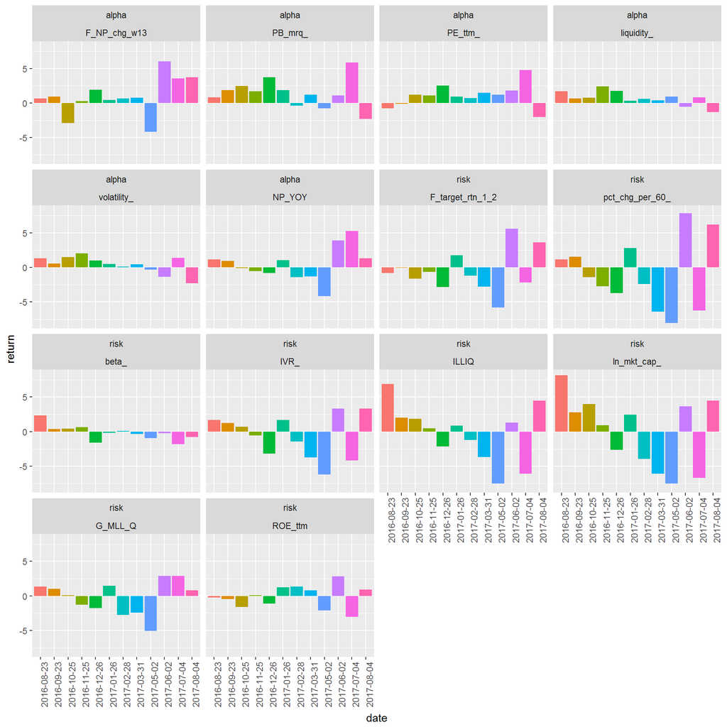

沪深300内得分最高的组**超额**收益率如下图所示。

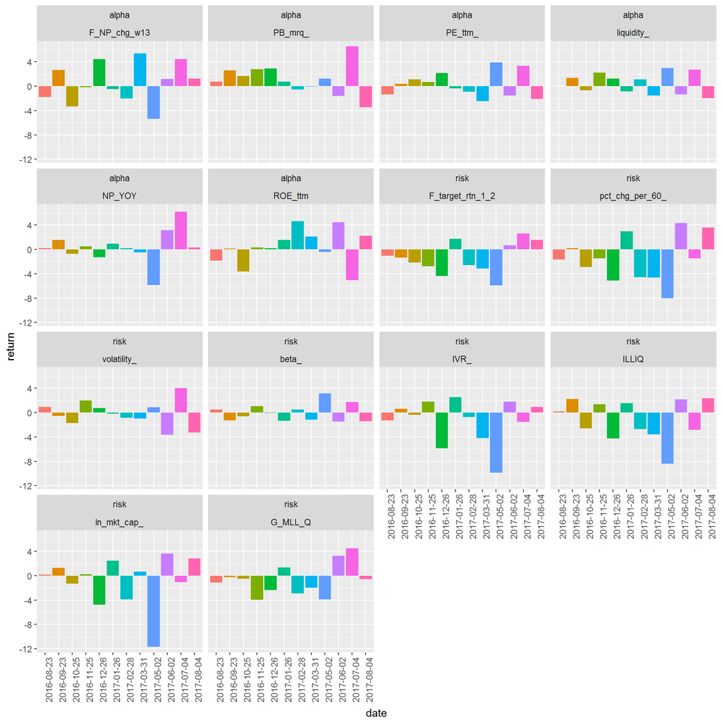

中证500内得分最高的组**超额**收益率如下图所示。

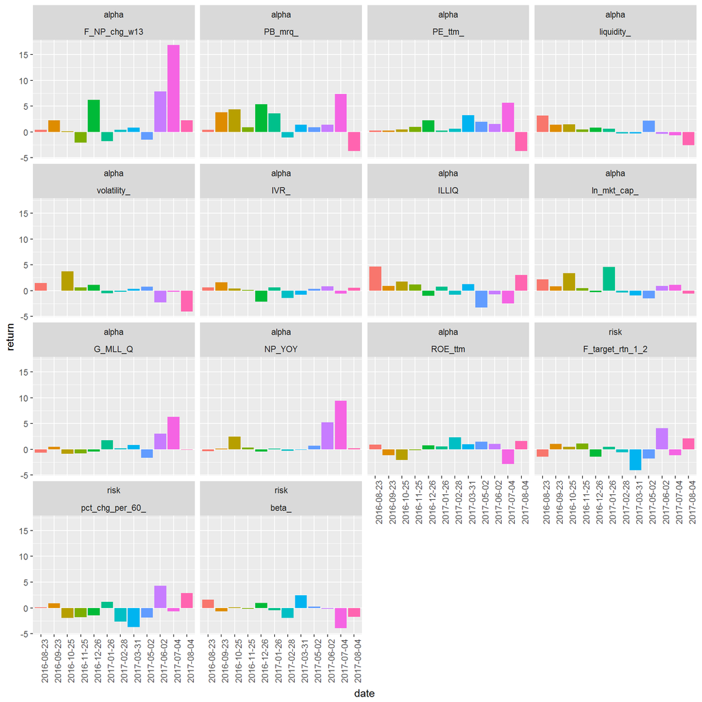

各个样本空间内，因子得分最高的一组和得分最低的一组的**超额**累积收益率统计如下表所示。

|  | 因子名 | 全市场Q1 | 全市场Q10 | 沪深300Q1 | 沪深300Q10 | 中证500Q1 | 中证500Q10 |
| --- | --- | --- | --- | --- | --- | --- | --- |
| 15 | PB_mrq_ | 18.3 | -22.4 | 14.1 | -22.2 | 27.1 | -5.8 |
| 16 | PE_ttm_ | 13.5 | -13.9 | 2.8 | -14.7 | 14.7 | -5.5 |
| 17 | F_NP_chg_w13 | 12.1 | -5.8 | 5.7 | -14.6 | 34.9 | -4.7 |
| 18 | liquidity_ | 8.8 | -32.9 | 5.3 | -27.7 | 6.1 | -13.6 |
| 19 | NP_YOY | 4.9 | -13.1 | 4.3 | -14.6 | 18.2 | -7.9 |
| 20 | volatility_ | 4.7 | -26.1 | -3.0 | -16.4 | 0.5 | -14.1 |
| 21 | ROE_ttm | -1.4 | -10.1 | 4.2 | 6.0 | 3.2 | -0.1 |
| 22 | ln_mkt_cap_ | -1.9 | 5.5 | -11.8 | 7.9 | 10.1 | 6.6 |
| 23 | beta_ | -2.1 | -22.0 | -0.6 | -23.1 | -3.9 | -15.8 |
| 24 | G_MLL_Q | -3.1 | -11.8 | -8.5 | -13.4 | 8.1 | -10.0 |
| 25 | ILLIQ | -3.6 | -3.8 | -14.2 | 4.5 | 5.0 | -8.1 |
| 26 | F_target_rtn_1_2 | -7.4 | -8.6 | -16.0 | -12.4 | -1.4 | -0.5 |
| 27 | IVR_ | -7.6 | -14.1 | -15.8 | -7.3 | 0.0 | -9.6 |
| 28 | pct_chg_per_60_ | -12.2 | -10.5 | -18.0 | -4.1 | -4.9 | -1.2 |